# The Elo method in chess

```r
library(ggplot2)
library(dplyr)

df <- read.csv("https://users.dimi.uniud.it/~massimo.franceschet/ns/plugandplay/challenges/chess/data.csv")
```

## Challenges

#1.Has the White an advantage over the Black, that is, is there a first-mover advantage?

```r
table(df$Score) / nrow(df)
```

```
##
##         0       0.5         1
## 0.2340246 0.4406561 0.3253194
```

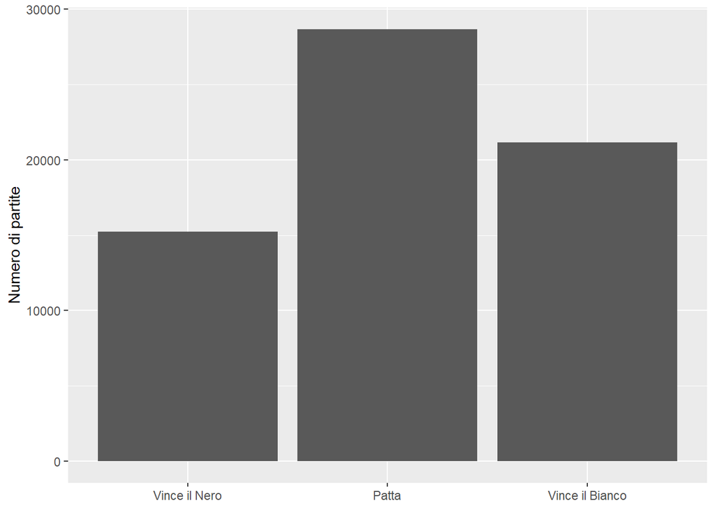

```r
ggplot(df, aes(x = factor(Score))) +
  geom_bar() +
  scale_x_discrete(labels = c("Vince il Nero", "Patta", "Vince il Bianco")) +
  labs(x = NULL, y = "Numero di partite")
```

Il Bianco vince più spesso del Nero, quindi esiste un vantaggio del primo mover.

#2. Write a function that computes the player point rating (1 point for wins, 0.5 points for draws, 0 points for defeats). How are point ratings distributed? Why?

```r
point_rating <- function(d) {
  bind_rows(data.frame(id = d$White, points = d$Score),
            data.frame(id = d$Black, points = 1 - d$Score)) |>
    group_by(id) |>
    summarise(points = sum(points), games = n())
}

players <- point_rating(df)
summary(players$points)
```

```
##    Min. 1st Qu.  Median    Mean 3rd Qu.    Max.
##    0.00    1.00    3.00    8.91    9.00  167.50
```

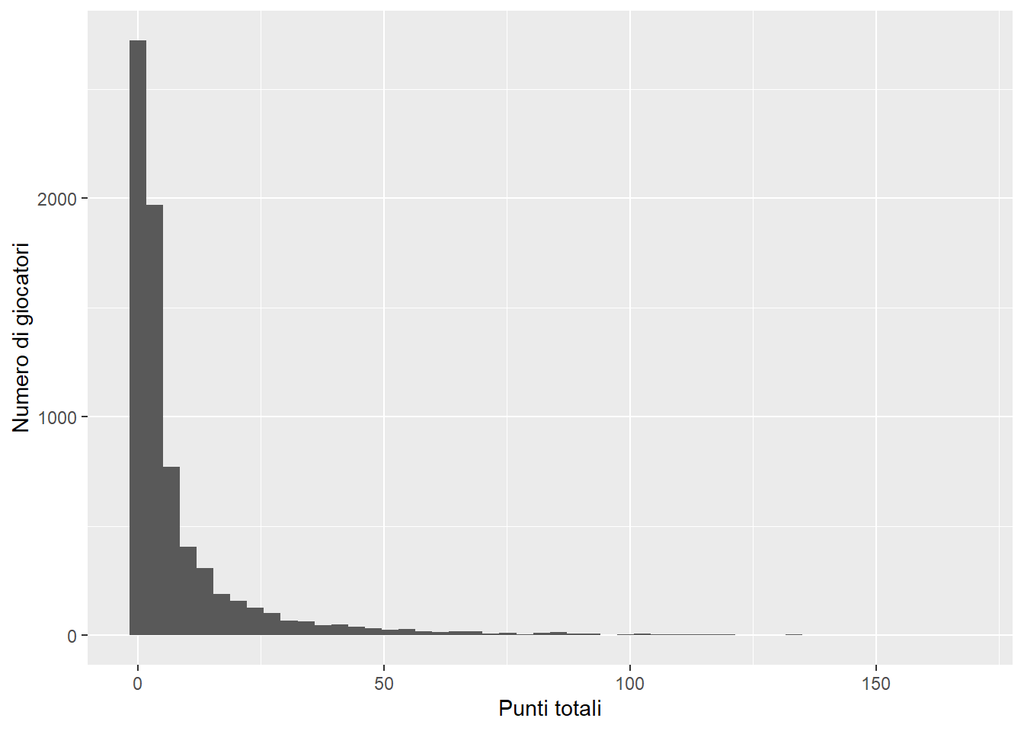

```r
ggplot(players, aes(x = points)) +
  geom_histogram(bins = 50) +
  labs(x = "Punti totali", y = "Numero di giocatori")
```

I punti hanno una distribuzione asimmetrica a destra, la maggior parte dei giocatori ha pochi punti, mentre pochi giocatori ne hanno moltissimi. Succede perché i punti dipendono dal numero di partite giocate, e poche persone giocano tante partite.

#3. An interesting property of Elo’s ratings is that the sum of all player ratings is always 0. Formally show this property. (Hint: use the fact that $s_{i,j} + s_{j,i}=1$ and $\mu_{i,j} + \mu_{j,i} =1$)

```r
zeta <- 400
kappa <- 25
mu <- function(ri, rj) 1 / (1 + 10^(-(ri - rj) / zeta))

g <- expand.grid(s_ij = c(0, 0.5, 1), ri = seq(-1000, 1000, 10), rj = seq(-1000, 1000, 10))
g$s_ji <- 1 - g$s_ij

delta_S <- kappa * (g$s_ij - mu(g$ri, g$rj)) + kappa * (g$s_ji - mu(g$rj, g$ri))
max(abs(delta_S))
```

```
## [1] 5.329071e-15
```

#4. Write a function that computes the player Elo rating (set $\zeta = 400$ and $\kappa = 25$) (Hint: take advantage of the 0-sum property to optimize the code). Obserse its distribution: why is different from the point distribution? Verify the 0-sum property for Elo’s ratings

```r
elo_rating <- function(d, zeta = 400, kappa = 25) {
  id <- unique(c(d$White, d$Black))
  w <- match(d$White, id)
  b <- match(d$Black, id)
  r <- numeric(length(id))
  for (k in seq_len(nrow(d))) {
    delta <- kappa * (d$Score[k] - 1 / (1 + 10^((r[b[k]] - r[w[k]]) / zeta)))
    r[w[k]] <- r[w[k]] + delta   # il Bianco guadagna delta
    r[b[k]] <- r[b[k]] - delta   # il Nero perde delta (0-sum)
  }
  data.frame(id, elo = r)
}

# tabella con punti, partite ed Elo (ricostruita da zero, si può rieseguire)
players <- point_rating(df) |> left_join(elo_rating(df), by = "id")

summary(players[c("points", "elo")])
```

```
##      points            elo
##  Min.   :  0.00   Min.   :-146.456
##  1st Qu.:  1.00   1st Qu.: -22.873
##  Median :  3.00   Median :  -6.005
##  Mean   :  8.91   Mean   :   0.000
##  3rd Qu.:  9.00   3rd Qu.:  12.476
##  Max.   :167.50   Max.   : 326.950
```

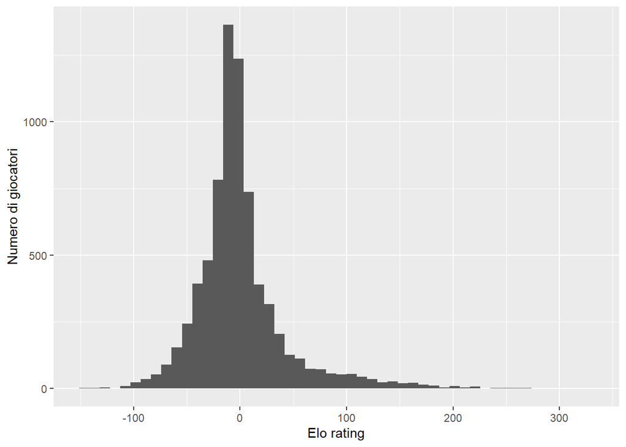

```r
ggplot(players, aes(x = elo)) +
  geom_histogram(bins = 50) +
  labs(x = "Elo rating", y = "Numero di giocatori")
```

```r
sum(players$elo)
```

```
## [1] 9.476309e-13
```

```r
all.equal(sum(players$elo), 0)
```

```
## [1] TRUE
```

I punti dipendono dal numero di partite giocate, mentre l’Elo misura quanto si va meglio o peggio del previsto: si guadagna battendo avversari forti e si perde con quelli deboli

#5. Are point and Elo ratings correlated? Are top Elo players overlapping with top point players?

```r
cor(players$elo, players$points, method = "spearman")
```

```
## [1] 0.406949
```

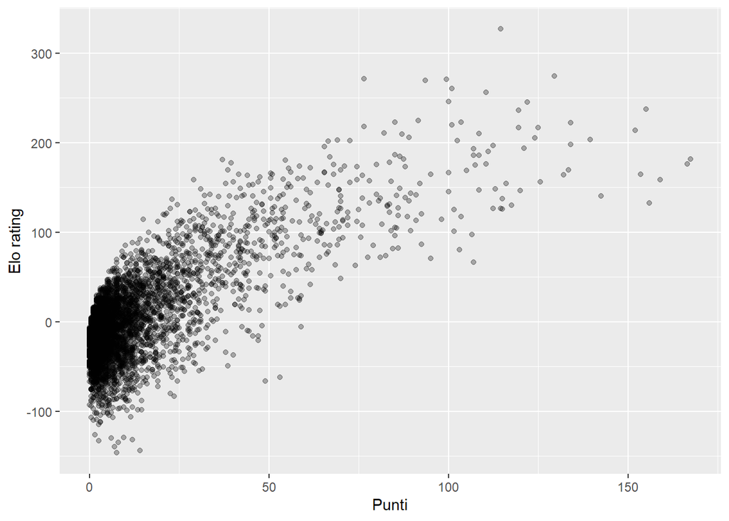

```r
ggplot(players, aes(x = points, y = elo)) +
  geom_point(alpha = 0.3) +
  labs(x = "Punti", y = "Elo rating")
```

```r
# quanti giocatori sono sia nei top 100 per Elo sia nei top 100 per punti
top_elo    <- players$id[order(-players$elo)][1:100]
top_points <- players$id[order(-players$points)][1:100]
length(intersect(top_elo, top_points))
```

```
## [1] 53
```

Sì, punti ed Elo sono correlati, ovvero chi vince di più ha di solito anche un Elo più alto, e nel grafico i punti salgono insieme

#6. Test if the number of played games has an effect on the Elo and point player ratings

```r
cor.test(players$games, players$points, method = "spearman")
```

```
##
##  Spearman's rank correlation rho
##
## data:  players$games and players$points
## S = 3424827271, p-value < 2.2e-16
## alternative hypothesis: true rho is not equal to 0
## sample estimates:
##       rho
## 0.9471989
```

```r
cor.test(players$games, players$elo,    method = "spearman")
```

```
##
##  Spearman's rank correlation rho
##
## data:  players$games and players$elo
## S = 5.3237e+10, p-value < 2.2e-16
## alternative hypothesis: true rho is not equal to 0
## sample estimates:
##       rho
## 0.1792341
```

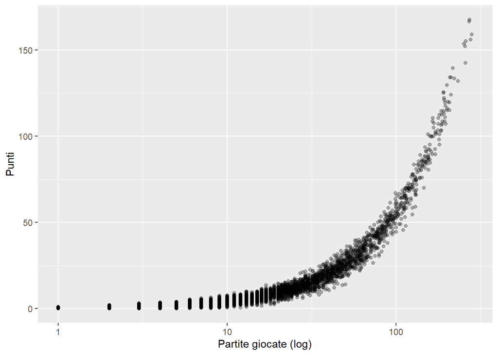

```r
ggplot(players, aes(x = games, y = points)) +
  geom_point(alpha = 0.3) +
  scale_x_log10() +
  labs(x = "Partite giocate (log)", y = "Punti")
```

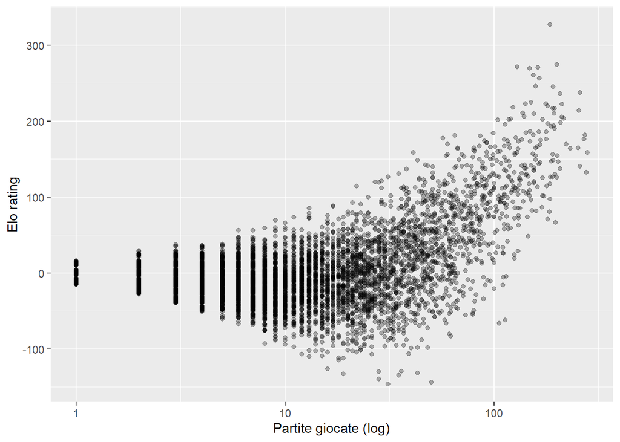

```r
ggplot(players, aes(x = games, y = elo)) +
  geom_point(alpha = 0.3) +
  scale_x_log10() +
  labs(x = "Partite giocate (log)", y = "Elo rating")
```

Il numero di partite ha un effetto forte sui punti, ovvero chi gioca di più accumula più punti, perché ogni partita ne aggiunge in media circa 0.5. Sull’Elo l’effetto è più debole, perché il rating dipende da come si gioca e non da quanto